# Predicting Cancer Cells

[figure not shown]

Machine Learning algorithm based on support vector machine to predict cancer cells

Published on **August 06, 2021** by [**Vimal Octavius PJ**](https://github.com/vimaloctavius)

Machine Learning SVM

**229 min** READ

Building a classification model using human cell records, and classify cells - whether the samples are benign or malignant.

This exercise uses [Support Vector Machine](https://scikit-learn.org/stable/modules/svm.html)

## About The Dataset

Dataset is publicly available at the [UCI Machine Learning Repository Asuncion and Newman, 2007](https://cml.ics.uci.edu/). It contains several hundred human cell sample records, each of which contains the values of a set of cell characteristics. The fields in each record are:

| Field name | Description |
| --- | --- |
| ID | Clump thickness |
| Clump | Clump thickness |
| UnifSize | Uniformity of cell size |
| UnifShape | Uniformity of cell shape |
| MargAdh | Marginal adhesion |
| SingEpiSize | Single epithelial cell size |
| BareNuc | Bare nuclei |
| BlandChrom | Bland chromatin |
| NormNucl | Normal nucleoli |
| Mit | Mitoses |
| Class | Benign or malignant |

```python
import warnings
warnings.filterwarnings('ignore')

import pandas as pd
import pylab as pl
import numpy as np
import scipy.optimize as opt
from sklearn import preprocessing
from sklearn.model_selection import train_test_split
%matplotlib inline
import matplotlib.pyplot as plt
```

## Reading the CSV file

```python
df_cell_data = pd.read_csv("/content/drive/MyDrive/Datasets/CancerCellSamples.csv")
df_cell_data.head()
```

|  | Unnamed: 0 | ID | Clump | UnifSize | UnifShape | MargAdh | SingEpiSize | BareNuc | BlandChrom | NormNucl | Mit | Class |
| --- | --- | --- | --- | --- | --- | --- | --- | --- | --- | --- | --- | --- |
| 0 | 0 | 1000025 | 5 | 1 | 1 | 1 | 2 | 1 | 3 | 1 | 1 | 2 |
| 1 | 1 | 1002945 | 5 | 4 | 4 | 5 | 7 | 10 | 3 | 2 | 1 | 2 |
| 2 | 2 | 1015425 | 3 | 1 | 1 | 1 | 2 | 2 | 3 | 1 | 1 | 2 |
| 3 | 3 | 1016277 | 6 | 8 | 8 | 1 | 3 | 4 | 3 | 7 | 1 | 2 |
| 4 | 4 | 1017023 | 4 | 1 | 1 | 3 | 2 | 1 | 3 | 1 | 1 | 2 |

Fields Clump, UnifSize, UnifShape, MargAdh, SingEpiSize, BareNuc, BlandChrom, NormNucl, Mit contain data where values are graded from 1 to 10. The closest to benign is 1.

The Class field has benign (value = 2) or malignant (value = 4).

The distribution of the classes based on Clump thickness and Uniformity of cell size may be visualized:

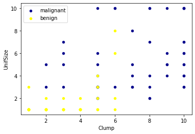

```python
ax = df_cell_data[df_cell_data['Class'] == 4][0:50].plot(kind='scatter', x='Clump', y='UnifSize', color='DarkBlue', label='malignant');
df_cell_data[df_cell_data['Class'] == 2][0:50].plot(kind='scatter', x='Clump', y='UnifSize', color='Yellow', label='benign', ax=ax);
plt.show()
```

## Data pre-processing and selection

A view of the columns' data types:

```python
df_cell_data.dtypes
```

```
Unnamed: 0      int64
ID              int64
Clump           int64
UnifSize        int64
UnifShape       int64
MargAdh         int64
SingEpiSize     int64
BareNuc        object
BlandChrom      int64
NormNucl        int64
Mit             int64
Class           int64
dtype: object
```

**BareNuc** column has values that are not numerical. Dropping these rows:

```python
df_cell_data = df_cell_data[pd.to_numeric(df_cell_data['BareNuc'], errors='coerce').notnull()]
df_cell_data['BareNuc'] = df_cell_data['BareNuc'].astype('int')
df_cell_data.dtypes
```

```
Unnamed: 0     int64
ID             int64
Clump          int64
UnifSize       int64
UnifShape      int64
MargAdh        int64
SingEpiSize    int64
BareNuc        int64
BlandChrom     int64
NormNucl       int64
Mit            int64
Class          int64
dtype: object
```

```python
df_features = df_cell_data[['Clump', 'UnifSize', 'UnifShape', 'MargAdh', 'SingEpiSize', 'BareNuc', 'BlandChrom', 'NormNucl', 'Mit']]
X = np.asarray(df_features)
X[0:5]
```

```
array([[ 5,  1,  1,  1,  2,  1,  3,  1,  1],
       [ 5,  4,  4,  5,  7, 10,  3,  2,  1],
       [ 3,  1,  1,  1,  2,  2,  3,  1,  1],
       [ 6,  8,  8,  1,  3,  4,  3,  7,  1],
       [ 4,  1,  1,  3,  2,  1,  3,  1,  1]])
```

The Model should predict Class, benign (=2) or malignant (=4). Let's change its measurement level:

```python
df_cell_data['Class'] = df_cell_data['Class'].astype('int')
y = np.asarray(df_cell_data['Class'])
y [0:5]
```

```
array([2, 2, 2, 2, 2])
```

## Splitting dataset into Training and Test sets

```python
X_train, X_test, y_train, y_test = train_test_split( X, y, test_size=0.2, random_state=4)
print ('Train set:', X_train.shape,  y_train.shape)
print ('Test set:', X_test.shape,  y_test.shape)
```

```
Train set: (546, 9) (546,)
Test set: (137, 9) (137,)
```

## Data Modeling (Support Vector Machine, Scikit-learn)

Mapping of data into a higher dimensional space is called kernelling. With SVM, there are a few kernel functions for processing. The mathematical function used for the transformation is called the kernel function, like:

```
1.Sigmoid
2.Polynomial
3.Radial basis function (RBF)
4.Linear
```

Each of these return different results, has Pros and Cons. Let's use the default RBF (Radial Basis Function)

```python
from sklearn import svm
clf = svm.SVC(kernel='rbf')
clf.fit(X_train, y_train)
```

```
SVC()
```

Prediction:

```python
yhat = clf.predict(X_test)
yhat [0:5]
```

```
array([2, 4, 2, 4, 2])
```

Evaluating the model

```python
from sklearn.metrics import classification_report, confusion_matrix
import itertools
```

```python
def confusion_matrix_plot(cm, classes,
                          normalize=False,
                          title='Confusion - Matrix',
                          cmap=plt.cm.Blues):
    """
    `normalize=True` applies Normalization
    Function to print and plot the confusion matrix
    """
    if normalize:
        cm = cm.astype('float') / cm.sum(axis=1)[:, np.newaxis]
        print("Confusion Matrix, Normalized")
    else:
        print('Confusion Matrix, not Normalized')

    print(cm)

    plt.imshow(cm, interpolation='nearest', cmap=cmap)
    plt.title(title)
    plt.colorbar()
    tick_marks = np.arange(len(classes))
    plt.xticks(tick_marks, classes, rotation=45)
    plt.yticks(tick_marks, classes)

    fmt = '.2f' if normalize else 'd'
    thresh = cm.max() / 2.
    for i, j in itertools.product(range(cm.shape[0]), range(cm.shape[1])):
        plt.text(j, i, format(cm[i, j], fmt),
                 horizontalalignment="center",
                 color="white" if cm[i, j] > thresh else "black")

    plt.tight_layout()
    plt.ylabel('True label')
    plt.xlabel('Predicted label')
```

```
              precision    recall  f1-score   support

           2       1.00      0.94      0.97        90
           4       0.90      1.00      0.95        47

    accuracy                           0.96       137
   macro avg       0.95      0.97      0.96       137
weighted avg       0.97      0.96      0.96       137

Confusion Matrix, not Normalized
[[85  5]
 [ 0 47]]
```

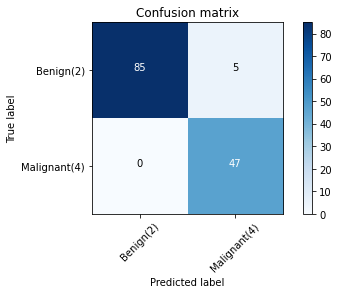

```python
# Compute confusion matrix
cnf_matrix = confusion_matrix(y_test, yhat, labels=[2,4])
np.set_printoptions(precision=2)

print (classification_report(y_test, yhat))

# Plot non-normalized confusion matrix
plt.figure()
confusion_matrix_plot(cnf_matrix, classes=['Benign(2)','Malignant(4)'],normalize= False,  title='Confusion matrix')
```

Using **f1_score** from sklearn library:

```python
from sklearn.metrics import f1_score
f1_score(y_test, yhat, average='weighted')
```

```
0.9639038982104676
```

Jaccard index for accuracy:

```python
from sklearn.metrics import jaccard_score
jaccard_score(y_test, yhat,pos_label=2)
```

```
0.9444444444444444
```

Building the model with Linear kernel:

```python
clf2 = svm.SVC(kernel='linear')
clf2.fit(X_train, y_train)
yhat2 = clf2.predict(X_test)
print("Avg F1-score: %.4f" % f1_score(y_test, yhat2, average='weighted'))
print("Jaccard score: %.4f" % jaccard_score(y_test, yhat2,pos_label=2))
```

```
Avg F1-score: 0.9639
Jaccard score: 0.9444
```